# DATA 624 - Homework 3

OMER OZEREN

Exercises 6.2 and 6.3 from the Hyndman online Forecasting book.

```r
#clear the workspace
rm(list = ls())
#load req's packages
library(forecast)
library(readxl)
library(RCurl)
library(fpp2)
library(seasonal)
```

## Question 6.2

The plastics data set consists of the monthly sales (in thousands) of product A for a plastics manufacturer for five years.

### A - Plot the timeseries

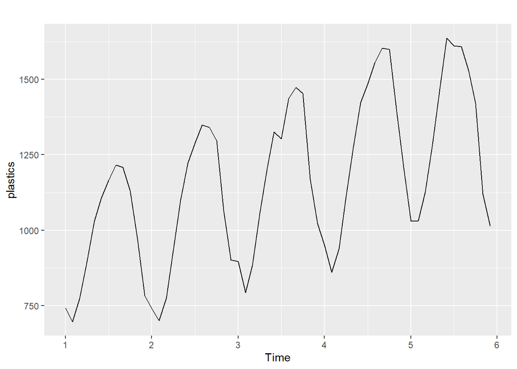

```r
autoplot(plastics)
```

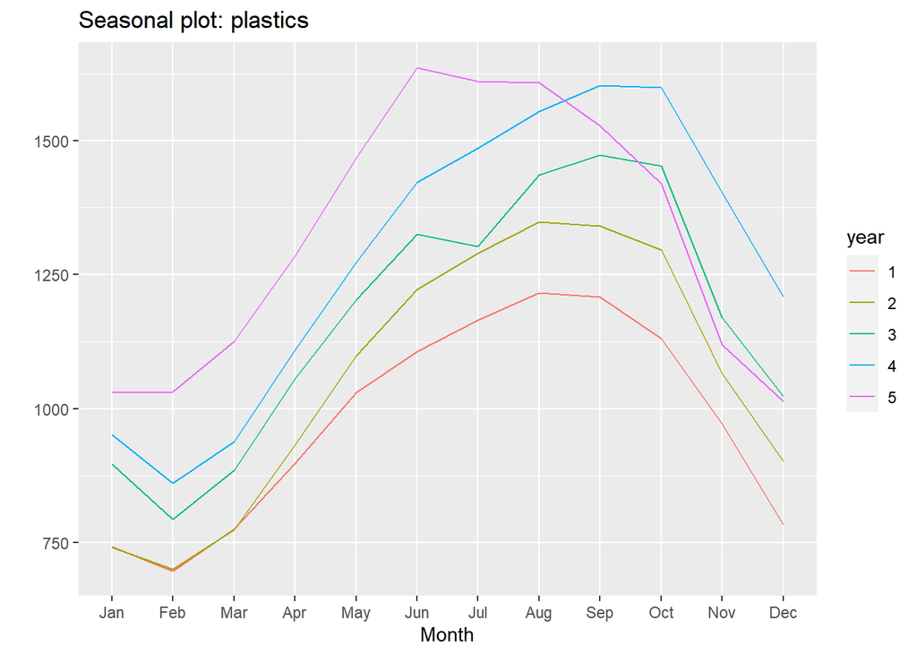

```r
ggseasonplot(plastics)
```

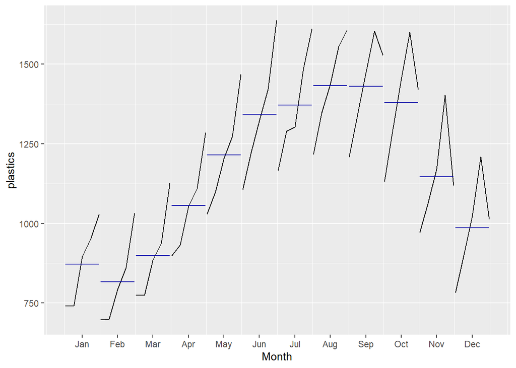

```r
ggsubseriesplot(plastics)
```

We see an apparent seasonality in the timeseries which is confirmed by the seasonal plot. Sales are at their seasonal low in Feb and at their seasonal high in Aug / Sept.

The sub-series plot shows an interesting pattern. For Sept to Dec, we see a shart reversal in the final data-points of the subseries plot. It could be indicitive of a change in the overall trend, or possibly a change in the season. There is not enough data here to draw a reasonable conclusion either way.

### B - Classical Multiplicative Decomposition

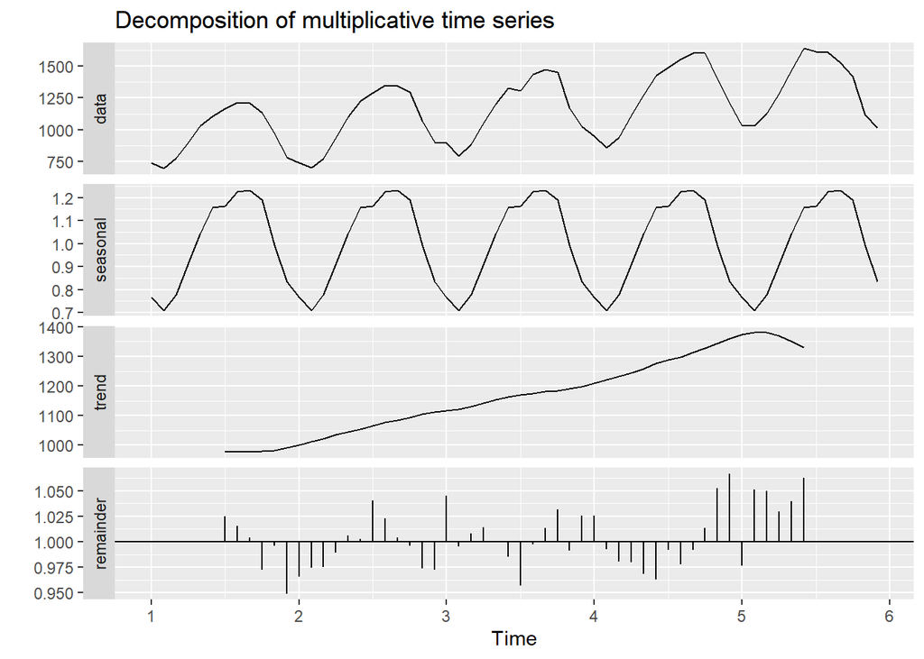

```r
mult.decomp <- decompose(plastics, type = "multiplicative")
autoplot(mult.decomp )
```

### C - Do your results from part B support interpretation from part A?

Yes. We can see a clear seasonal pattern and in addition, we see a downturn in the trend in year 5, as suggested as a possibility based on the sub-series plots.

### D - Compute and plot the seasonally adjusted data

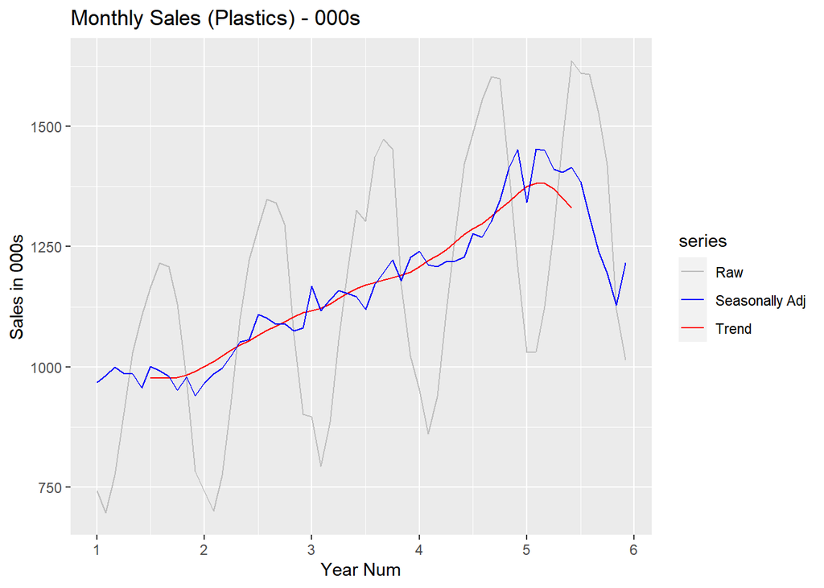

```r
autoplot(plastics, series="Raw") +
  autolayer(trendcycle(mult.decomp), series="Trend") +
  autolayer(seasadj(mult.decomp), series="Seasonally Adj") +
  xlab("Year Num") + ylab("Sales in 000s") +
  ggtitle("Monthly Sales (Plastics) - 000s") +
  scale_colour_manual(values=c("gray","blue","red"),
             breaks=c("Raw","Seasonally Adj","Trend"))
```

### E - Inject an outlier

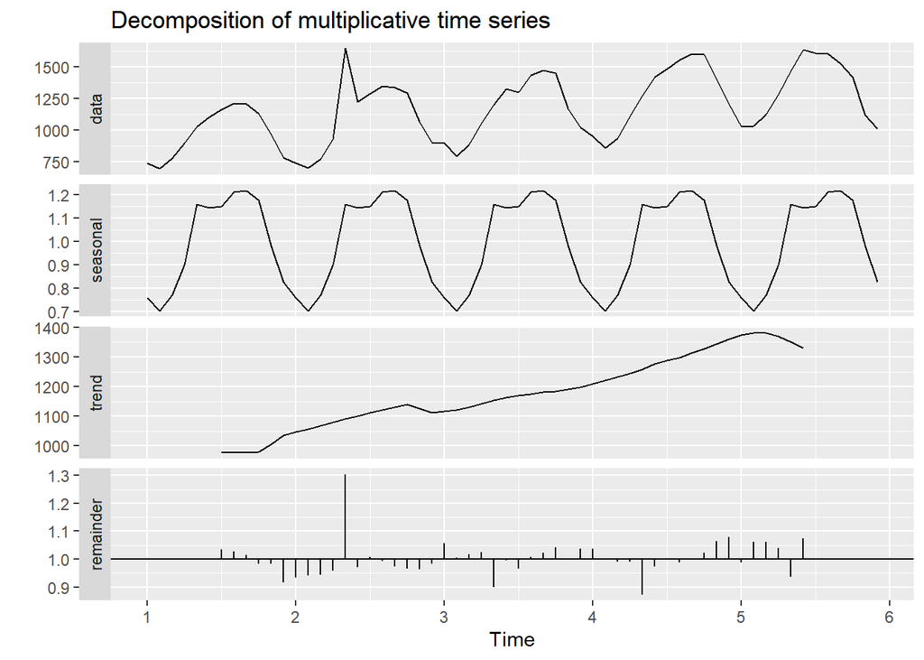

```r
#randomly inject an outlier between 500-1000
p.mod <- plastics
rnd.index <- sample(1:length(plastics),1)
p.mod[rnd.index] <- p.mod[rnd.index]+ (sample(500:1000,1) * sample(c(-1,1),1))
#re-run all the above
mult.decomp <- decompose(p.mod, type = "multiplicative")
autoplot(mult.decomp )
```

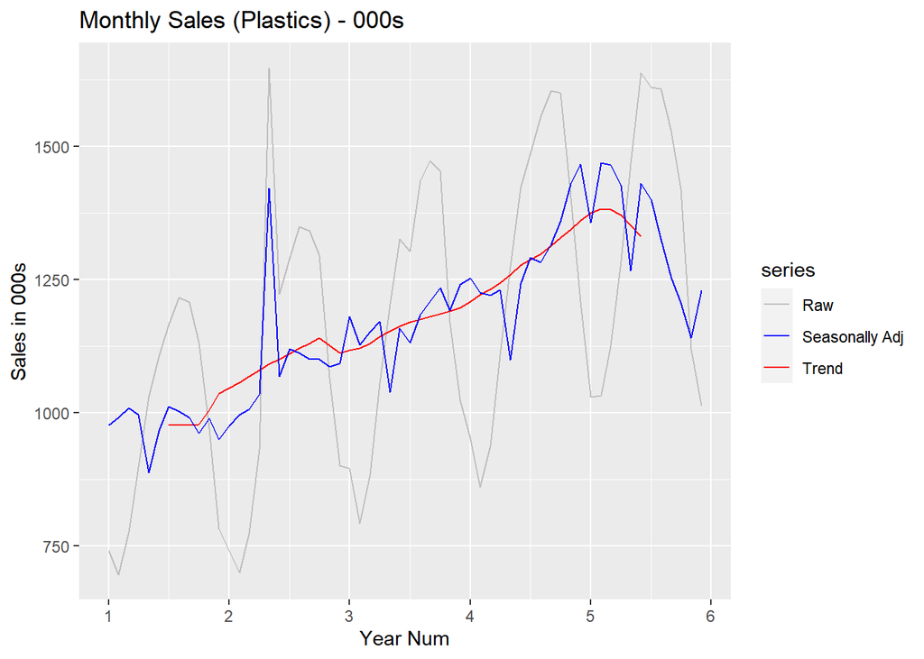

```r
autoplot(p.mod , series="Raw") +
  autolayer(trendcycle(mult.decomp), series="Trend") +
  autolayer(seasadj(mult.decomp), series="Seasonally Adj") +
  xlab("Year Num") + ylab("Sales in 000s") +
  ggtitle("Monthly Sales (Plastics) - 000s") +
  scale_colour_manual(values=c("gray","blue","red"),
             breaks=c("Raw","Seasonally Adj","Trend"))
```

The trend component is generally insensitive to outliers of the magnitude selected and that the seasonal component is highly sensitive - in this case, we appear to get a major cyclical blip in the seasonally adjusted data. The sign of the outlier doesn’t appear to be important as it pertains to either of these observations.